# Report

Nick Parker

3/13/2022

## Project Description

- When a mother works for pay, the children suffer
- When jobs are scarce, employers should give priority to [NATIONALITY] people over immigrants

The data used in this analysis was generated as part of the 2017 European Value Study (EVS). The EVS is described as “a large-scale, cross-national and longitudinal survey research program on how Europeans think about family, work, religion, politics, and society. Repeated every nine years in an increasing number of countries, the survey provides insights into the ideas, beliefs, preferences, attitudes, values, and opinions of citizens all over Europe.”

## Descriptive Statistics

```r
library(tidyverse)
library(haven)
library(psych)
library(texreg)

data <- read_dta("/Users/nicholasparker/Dropbox/JPSM/MWDS/EVS/ZA7500_v4-0-0.dta")

data_clean <- data %>%
  select(v72,v80,v52,v261,v243_r,c_abrv,v225, age) %>%
  rename("suffering_mother"=v72) %>%
  rename("jobs_scarce"= v80) %>%
  rename("religion"= v52) %>%
  rename("sex"= v225) %>%
  rename("education"= v243_r) %>%
  rename("country"= c_abrv) %>%
  rename("income" = v261)
```

|  | vars | n | mean | sd | median | trimmed | mad | min | max | range | skew | kurtosis | se |
| --- | --- | --- | --- | --- | --- | --- | --- | --- | --- | --- | --- | --- | --- |
| income | 1 | 56491 | 3.95132 | 3.616743 | 4 | 4.070896 | 4.4478 | -10 | 10 | 20 | -0.289702 | -0.5218019 | 0.0152170 |
| age | 2 | 56491 | 49.36004 | 18.096869 | 50 | 49.397362 | 22.2390 | -2 | 82 | 84 | -0.076798 | -0.8510073 | 0.0761402 |

|  | suffering_mother | jobs_scarce | religion | education | country | sex |
| --- | --- | --- | --- | --- | --- | --- |
|  | Min. :-2.000 | Min. :-10.000 | Min. :-3.000 | Min. :-2.000 | Length:56491 | Min. :-2.000 |
|  | 1st Qu.: 2.000 | 1st Qu.: 1.000 | 1st Qu.:-3.000 | 1st Qu.: 2.000 | Class :character | 1st Qu.: 1.000 |
|  | Median : 3.000 | Median : 2.000 | Median : 1.000 | Median : 2.000 | Mode :character | Median : 2.000 |
|  | Mean : 2.629 | Mean : 2.283 | Mean : 1.732 | Mean : 2.192 | NA | Mean : 1.552 |
|  | 3rd Qu.: 3.000 | 3rd Qu.: 3.000 | 3rd Qu.: 5.000 | 3rd Qu.: 3.000 | NA | 3rd Qu.: 2.000 |
|  | Max. : 4.000 | Max. : 5.000 | Max. : 9.000 | Max. :66.000 | NA | Max. : 2.000 |

## Figures

Figure 1 illustrates that, as the age of a respondent increases, they are more likely to agree with the idea that mothers choosing to work for pay will harm their children. This relationship also appears to hold true for the statement that when jobs are scarce, they should be given to citizens before imigrants.

Figure 2 illustrates the mean response for various religious groups. Respondents from the Orthodox, Muslim, and Roman Catholic faiths seem more likely to agree that when jobs are scarce, they should be given to citizens before imigrants. When it comes to the statement about mothers choosing to work for pay harming their children, there is less dispersion among religious groups.

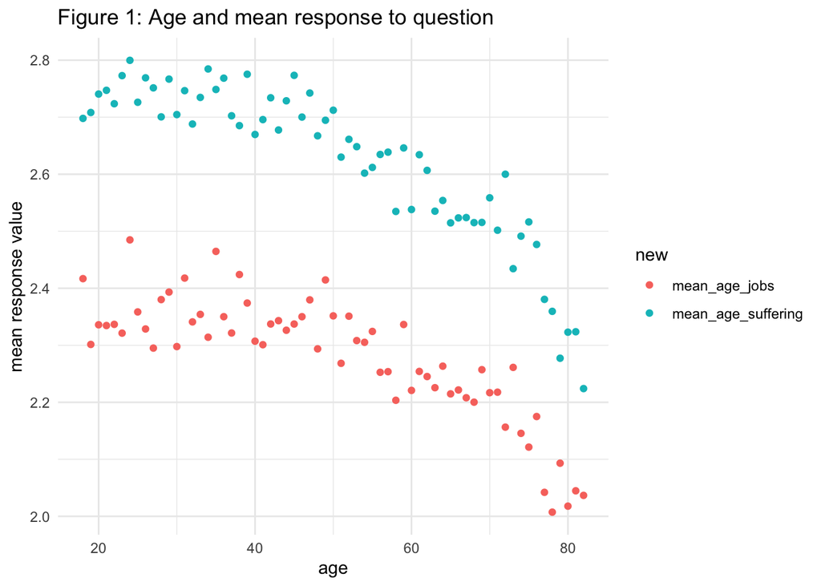

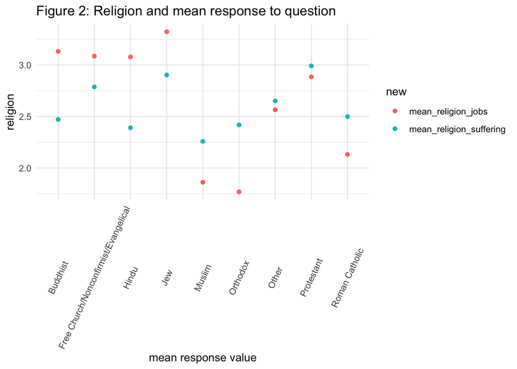

## Statistical Tests

As the level of educational attainment of a respondent increases, so too does their level of disagreement with the statement that a mother’s choice to work outside the homes harms her children. Women are also more likely to disagree with this statement. As the age of a respondent increases, they are more likely to agree with this statement.

Regression Estimation Results

|  | Working Mother | Job Scarcity |
| --- | --- | --- |
| (Intercept) | 2.74*** | 2.46*** |
|  | (0.02) | (0.02) |
| education | 0.02*** | 0.03*** |
|  | (0.00) | (0.00) |
| age | -0.01*** | -0.00*** |
|  | (0.00) | (0.00) |
| sex | 0.08*** | -0.03* |
|  | (0.01) | (0.01) |
| R<sup>2</sup> | 0.01 | 0.01 |
| Adj. R<sup>2</sup> | 0.01 | 0.01 |
| Num. obs. | 56491 | 56491 |

***p < 0.001; **p < 0.01; *p < 0.05